# Biostat 212a Homework 5

### 3.2 SVM with Polynomial Kernel

```r
# Load libraries
library(GGally)
library(gtsummary)
library(kernlab)
library(tidyverse)
library(tidymodels)
library(ISLR2)

# For reproducibility
set.seed(203)

# creating an outcome variable
carseats <- Carseats %>%
  mutate(SalesHL = ifelse(Sales <= 8, "Low", "High")) %>%
  select(-Sales)

# Numerical summaries stratified by the outcome `SalesHL`.
carseats %>% tbl_summary(by = SalesHL)
```

| **Characteristic** | **High**, N = 164<sup>1</sup> | **Low**, N = 236<sup>1</sup> |
| --- | --- | --- |
| CompPrice | 127 (115, 136) | 124 (115, 134) |
| Income | 76 (58, 94) | 65 (40, 88) |
| Advertising | 10.0 (0.0, 14.0) | 3.0 (0.0, 10.0) |
| Population | 276 (150, 403) | 268 (132, 389) |
| Price | 107 (90, 123) | 122 (107, 135) |
| ShelveLoc |  |  |
| Bad | 14 (8.5%) | 82 (35%) |
| Good | 66 (40%) | 19 (8.1%) |
| Medium | 84 (51%) | 135 (57%) |
| Age | 49 (36, 61) | 58 (42, 70) |
| Education |  |  |
| 10 | 25 (15%) | 23 (9.7%) |
| 11 | 17 (10%) | 31 (13%) |
| 12 | 19 (12%) | 30 (13%) |
| 13 | 17 (10%) | 26 (11%) |
| 14 | 14 (8.5%) | 26 (11%) |
| 15 | 18 (11%) | 18 (7.6%) |
| 16 | 18 (11%) | 29 (12%) |
| 17 | 21 (13%) | 28 (12%) |
| 18 | 15 (9.1%) | 25 (11%) |
| Urban | 110 (67%) | 172 (73%) |
| US | 123 (75%) | 135 (57%) |

<sup>1</sup> Median (IQR); n (%)

```r
data_split <- initial_split(
  carseats,
  strata = "SalesHL",
  prop = 0.75
  )
data_split
```

```
<Training/Testing/Total>
<300/100/400>
```

```r
carseats_train <- training(data_split)
dim(carseats_train)
```

```
[1] 300  11
```

```r
carseats_test <- testing(data_split)
dim(carseats_test)
```

```
[1] 100  11
```

```r
svm_recipe <-
  recipe(
    SalesHL ~ .,
    data = carseats_train
  ) %>%
  # create traditional dummy variables (necessary for svm)
  step_dummy(all_nominal_predictors()) %>%
  # zero-variance filter
  step_zv(all_numeric_predictors()) %>%
  # center and scale numeric data
  step_normalize(all_numeric_predictors())
  # estimate the means and standard deviations
  # prep(training = Heart_other, retain = TRUE)
svm_recipe

svm_mod <-
  svm_poly(
    mode = "classification",
    cost = tune(),
    degree = tune(),
  ) %>%
  set_engine("kernlab")
svm_mod
```

```
Polynomial Support Vector Machine Model Specification (classification)

Main Arguments:
  cost = tune()
  degree = tune()

Computational engine: kernlab
```

```r
svm_wf <- workflow() %>%
  add_recipe(svm_recipe) %>%
  add_model(svm_mod)
svm_wf
```

```
══ Workflow ════════════════════════════════════════════════════════════════════
Preprocessor: Recipe
Model: svm_poly()

── Preprocessor ────────────────────────────────────────────────────────────────
3 Recipe Steps

• step_dummy()
• step_zv()
• step_normalize()

── Model ───────────────────────────────────────────────────────────────────────
Polynomial Support Vector Machine Model Specification (classification)

Main Arguments:
  cost = tune()
  degree = tune()

Computational engine: kernlab
```

```r
param_grid <- grid_regular(
  cost(range = c(-3, 2)),
  degree(range = c(1, 5)),
  #scale_factor(range = c(-1, 1)),
  levels = c(5, 5)
  )
param_grid
```

```
# A tibble: 25 × 2
    cost degree
   <dbl>  <dbl>
 1 0.125      1
 2 0.297      1
 3 0.707      1
 4 1.68       1
 5 4          1
 6 0.125      2
 7 0.297      2
 8 0.707      2
 9 1.68       2
10 4          2
# ℹ 15 more rows
```

```r
set.seed(203)

folds <- vfold_cv(carseats_train, v = 5)
folds
```

```
#  5-fold cross-validation
# A tibble: 5 × 2
  splits           id
  <list>           <chr>
1 <split [240/60]> Fold1
2 <split [240/60]> Fold2
3 <split [240/60]> Fold3
4 <split [240/60]> Fold4
5 <split [240/60]> Fold5
```

```r
svm_fit <- svm_wf %>%
  tune_grid(
    resamples = folds,
    grid = param_grid,
    metrics = metric_set(roc_auc, accuracy)
    )
svm_fit
```

```
# Tuning results
# 5-fold cross-validation
# A tibble: 5 × 4
  splits           id    .metrics          .notes
  <list>           <chr> <list>            <list>
1 <split [240/60]> Fold1 <tibble [50 × 6]> <tibble [0 × 3]>
2 <split [240/60]> Fold2 <tibble [50 × 6]> <tibble [0 × 3]>
3 <split [240/60]> Fold3 <tibble [50 × 6]> <tibble [0 × 3]>
4 <split [240/60]> Fold4 <tibble [50 × 6]> <tibble [0 × 3]>
5 <split [240/60]> Fold5 <tibble [50 × 6]> <tibble [0 × 3]>
```

```
# A tibble: 50 × 8
    cost degree .metric  .estimator  mean     n std_err .config
   <dbl>  <dbl> <chr>    <chr>      <dbl> <int>   <dbl> <chr>
 1 0.125      1 accuracy binary     0.87      5 0.00972 Preprocessor1_Model01
 2 0.125      1 roc_auc  binary     0.952     5 0.00676 Preprocessor1_Model01
 3 0.297      1 accuracy binary     0.887     5 0.00816 Preprocessor1_Model02
 4 0.297      1 roc_auc  binary     0.954     5 0.00814 Preprocessor1_Model02
 5 0.707      1 accuracy binary     0.89      5 0.00667 Preprocessor1_Model03
 6 0.707      1 roc_auc  binary     0.955     5 0.00668 Preprocessor1_Model03
 7 1.68       1 accuracy binary     0.887     5 0.00624 Preprocessor1_Model04
 8 1.68       1 roc_auc  binary     0.956     5 0.00590 Preprocessor1_Model04
 9 4          1 accuracy binary     0.89      5 0.00408 Preprocessor1_Model05
10 4          1 roc_auc  binary     0.956     5 0.00549 Preprocessor1_Model05
# ℹ 40 more rows
```

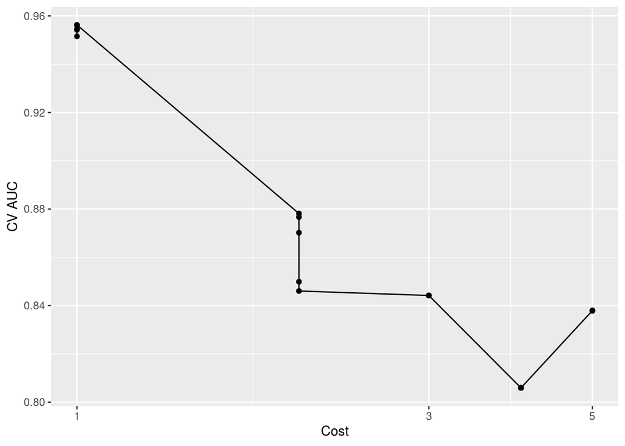

```r
svm_fit %>%
  collect_metrics() %>%
  print(width = Inf) %>%
  filter(.metric == "roc_auc" ) %>%
  ggplot(mapping = aes(x = degree, y = mean)) +
  geom_point() +
  geom_line() +
  labs(x = "Cost", y = "CV AUC") +
  scale_x_log10()
```

```r
svm_fit %>%
  show_best("roc_auc")
```

```
# A tibble: 5 × 8
   cost degree .metric .estimator  mean     n std_err .config
  <dbl>  <dbl> <chr>   <chr>      <dbl> <int>   <dbl> <chr>
1 4          1 roc_auc binary     0.956     5 0.00549 Preprocessor1_Model05
2 1.68       1 roc_auc binary     0.956     5 0.00590 Preprocessor1_Model04
3 0.707      1 roc_auc binary     0.955     5 0.00668 Preprocessor1_Model03
4 0.297      1 roc_auc binary     0.954     5 0.00814 Preprocessor1_Model02
5 0.125      1 roc_auc binary     0.952     5 0.00676 Preprocessor1_Model01
```

```r
best_svm <- svm_fit %>%
  select_best("roc_auc")
best_svm
```

```
# A tibble: 1 × 3
   cost degree .config
  <dbl>  <dbl> <chr>
1     4      1 Preprocessor1_Model05
```

```r
# Final workflow
final_wf <- svm_wf %>%
  finalize_workflow(best_svm)
final_wf
```

```
══ Workflow ════════════════════════════════════════════════════════════════════
Preprocessor: Recipe
Model: svm_poly()

── Preprocessor ────────────────────────────────────────────────────────────────
3 Recipe Steps

• step_dummy()
• step_zv()
• step_normalize()

── Model ───────────────────────────────────────────────────────────────────────
Polynomial Support Vector Machine Model Specification (classification)

Main Arguments:
  cost = 4
  degree = 1

Computational engine: kernlab
```

```r
# Fit the whole training set, then predict the test cases
final_fit <-
  final_wf %>%
  last_fit(data_split)
final_fit
```

```
# Resampling results
# Manual resampling
# A tibble: 1 × 6
  splits            id               .metrics .notes   .predictions .workflow
  <list>            <chr>            <list>   <list>   <list>       <list>
1 <split [300/100]> train/test split <tibble> <tibble> <tibble>     <workflow>
```

```r
# Test metrics
final_fit %>%
  collect_metrics()
```

```
# A tibble: 2 × 4
  .metric  .estimator .estimate .config
  <chr>    <chr>          <dbl> <chr>
1 accuracy binary         0.91  Preprocessor1_Model1
2 roc_auc  binary         0.971 Preprocessor1_Model1
```

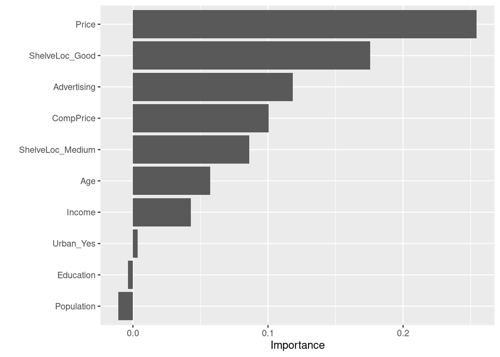

```r
library(doParallel)
set.seed(101)
split_obj <- initial_split(data = carseats, prop = 0.7, strata = SalesHL)
train <- training(split_obj)
test <- testing(split_obj)


# Create the recipe
recipe(SalesHL ~ ., data = train) %>%
  # create traditional dummy variables (necessary for svm)
  step_dummy(all_nominal_predictors()) %>%
  # zero-variance filter
  step_zv(all_numeric_predictors()) %>%
  # center and scale numeric data
  step_normalize(all_numeric_predictors()) %>%
  # estimate the means and standard deviations
  prep() -> recipe_obj

# Bake
train <- bake(recipe_obj, new_data=train)
test <- bake(recipe_obj, new_data=test)

library(vip)
final_fit %>%
  pluck(".workflow", 1) %>%
  pull_workflow_fit() %>%
  # vip(method = "permute", train= Heart)
  vip(method = "permute",
      target = "SalesHL", metric = "accuracy",
      pred_wrapper = kernlab::predict, train = train)
```

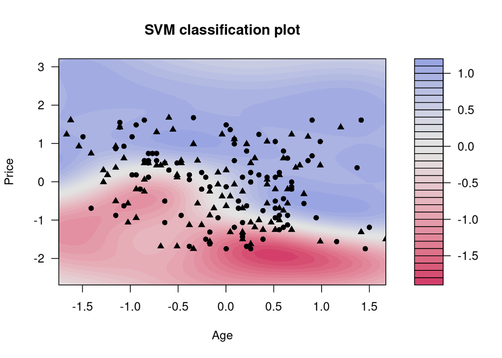

```r
svm_rbf_spec <- svm_rbf() %>%
  set_mode("classification") %>%
  set_engine("kernlab")

svm_rbf_fit <- svm_rbf_spec %>%
  fit(SalesHL ~ ., data = train[, c('Price', 'Age', 'SalesHL')])

svm_rbf_fit %>%
  extract_fit_engine() %>%
  plot()
```

### 3.3 SVM with Linear Kernel

```r
# Load libraries
library(GGally)
library(gtsummary)
library(kernlab)
library(tidyverse)
library(tidymodels)
library(ISLR2)

# For reproducibility
set.seed(203)

# creating an outcome variable
carseats <- Carseats %>%
  mutate(SalesHL = ifelse(Sales <= 8, "Low", "High")) %>%
  select(-Sales)

# Numerical summaries stratified by the outcome `SalesHL`.
carseats %>% tbl_summary(by = SalesHL)
```

| **Characteristic** | **High**, N = 164<sup>1</sup> | **Low**, N = 236<sup>1</sup> |
| --- | --- | --- |
| CompPrice | 127 (115, 136) | 124 (115, 134) |
| Income | 76 (58, 94) | 65 (40, 88) |
| Advertising | 10.0 (0.0, 14.0) | 3.0 (0.0, 10.0) |
| Population | 276 (150, 403) | 268 (132, 389) |
| Price | 107 (90, 123) | 122 (107, 135) |
| ShelveLoc |  |  |
| Bad | 14 (8.5%) | 82 (35%) |
| Good | 66 (40%) | 19 (8.1%) |
| Medium | 84 (51%) | 135 (57%) |
| Age | 49 (36, 61) | 58 (42, 70) |
| Education |  |  |
| 10 | 25 (15%) | 23 (9.7%) |
| 11 | 17 (10%) | 31 (13%) |
| 12 | 19 (12%) | 30 (13%) |
| 13 | 17 (10%) | 26 (11%) |
| 14 | 14 (8.5%) | 26 (11%) |
| 15 | 18 (11%) | 18 (7.6%) |
| 16 | 18 (11%) | 29 (12%) |
| 17 | 21 (13%) | 28 (12%) |
| 18 | 15 (9.1%) | 25 (11%) |
| Urban | 110 (67%) | 172 (73%) |
| US | 123 (75%) | 135 (57%) |

<sup>1</sup> Median (IQR); n (%)

```r
data_split <- initial_split(
  carseats,
  strata = "SalesHL",
  prop = 0.75
  )
data_split
```

```
<Training/Testing/Total>
<300/100/400>
```

```r
carseats_train <- training(data_split)
dim(carseats_train)
```

```
[1] 300  11
```

```r
carseats_test <- testing(data_split)
dim(carseats_test)
```

```
[1] 100  11
```

```r
svm_recipe <-
  recipe(
    SalesHL ~ .,
    data = carseats_train
  ) %>%
  # create traditional dummy variables (necessary for svm)
  step_dummy(all_nominal_predictors()) %>%
  # zero-variance filter
  step_zv(all_numeric_predictors()) %>%
  # center and scale numeric data
  step_normalize(all_numeric_predictors())
  # estimate the means and standard deviations
  # prep(training = Heart_other, retain = TRUE)
svm_recipe

# model for linear
svm_mod <-
  svm_linear(
    mode = "classification",
    cost = tune()
  ) %>%
  set_engine("kernlab")
svm_mod
```

```
Linear Support Vector Machine Model Specification (classification)

Main Arguments:
  cost = tune()

Computational engine: kernlab
```

```r
svm_wf <- workflow() %>%
  add_recipe(svm_recipe) %>%
  add_model(svm_mod)
svm_wf
```

```
══ Workflow ════════════════════════════════════════════════════════════════════
Preprocessor: Recipe
Model: svm_linear()

── Preprocessor ────────────────────────────────────────────────────────────────
3 Recipe Steps

• step_dummy()
• step_zv()
• step_normalize()

── Model ───────────────────────────────────────────────────────────────────────
Linear Support Vector Machine Model Specification (classification)

Main Arguments:
  cost = tune()

Computational engine: kernlab
```

```r
param_grid <- grid_regular(
  cost(range = c(-1, 4)),
  levels = c(5)
  )
param_grid
```

```
# A tibble: 5 × 1
   cost
  <dbl>
1  0.5
2  1.19
3  2.83
4  6.73
5 16
```

```r
set.seed(203)

folds <- vfold_cv(carseats_train, v = 5)
folds
```

```
#  5-fold cross-validation
# A tibble: 5 × 2
  splits           id
  <list>           <chr>
1 <split [240/60]> Fold1
2 <split [240/60]> Fold2
3 <split [240/60]> Fold3
4 <split [240/60]> Fold4
5 <split [240/60]> Fold5
```

```
# A tibble: 10 × 7
    cost .metric  .estimator  mean     n std_err .config
   <dbl> <chr>    <chr>      <dbl> <int>   <dbl> <chr>
 1  0.5  accuracy binary     0.893     5 0.00667 Preprocessor1_Model1
 2  0.5  roc_auc  binary     0.952     5 0.00719 Preprocessor1_Model1
 3  1.19 accuracy binary     0.887     5 0.00624 Preprocessor1_Model2
 4  1.19 roc_auc  binary     0.955     5 0.00650 Preprocessor1_Model2
 5  2.83 accuracy binary     0.893     5 0.00408 Preprocessor1_Model3
 6  2.83 roc_auc  binary     0.956     5 0.00584 Preprocessor1_Model3
 7  6.73 accuracy binary     0.89      5 0.00408 Preprocessor1_Model4
 8  6.73 roc_auc  binary     0.958     5 0.00571 Preprocessor1_Model4
 9 16    accuracy binary     0.89      5 0.00667 Preprocessor1_Model5
10 16    roc_auc  binary     0.957     5 0.00695 Preprocessor1_Model5
```

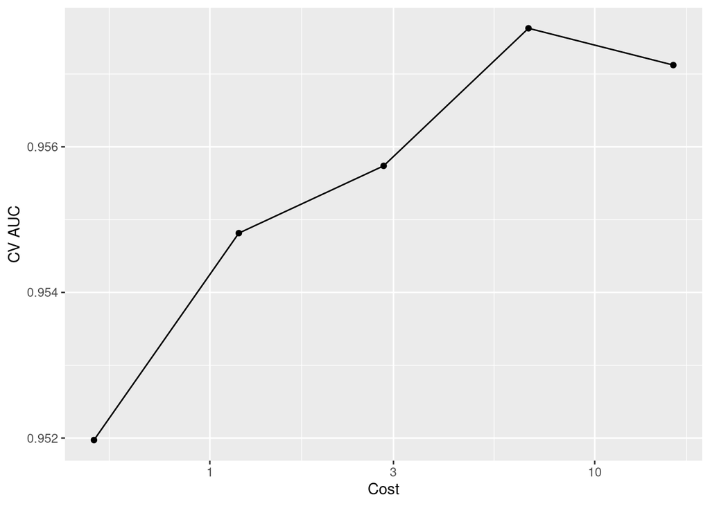

```r
svm_fit <- svm_wf %>%
  tune_grid(
    resamples = folds,
    grid = param_grid,
    metrics = metric_set(roc_auc, accuracy)
    )

svm_fit %>%
  collect_metrics() %>%
  print(width = Inf) %>%
  filter(.metric == "roc_auc" ) %>%
  ggplot(mapping = aes(x = cost, y = mean)) +
  geom_point() +
  geom_line() +
  labs(x = "Cost", y = "CV AUC") +
  scale_x_log10()
```

```r
svm_fit %>%
  show_best("roc_auc")
```

```
# A tibble: 5 × 7
   cost .metric .estimator  mean     n std_err .config
  <dbl> <chr>   <chr>      <dbl> <int>   <dbl> <chr>
1  6.73 roc_auc binary     0.958     5 0.00571 Preprocessor1_Model4
2 16    roc_auc binary     0.957     5 0.00695 Preprocessor1_Model5
3  2.83 roc_auc binary     0.956     5 0.00584 Preprocessor1_Model3
4  1.19 roc_auc binary     0.955     5 0.00650 Preprocessor1_Model2
5  0.5  roc_auc binary     0.952     5 0.00719 Preprocessor1_Model1
```

```r
best_svm <- svm_fit %>%
  select_best("roc_auc")

# Final workflow
final_wf <- svm_wf %>%
  finalize_workflow(best_svm)
final_wf
```

```
══ Workflow ════════════════════════════════════════════════════════════════════
Preprocessor: Recipe
Model: svm_linear()

── Preprocessor ────────────────────────────────────────────────────────────────
3 Recipe Steps

• step_dummy()
• step_zv()
• step_normalize()

── Model ───────────────────────────────────────────────────────────────────────
Linear Support Vector Machine Model Specification (classification)

Main Arguments:
  cost = 6.72717132202972

Computational engine: kernlab
```

```r
# Fit the whole training set, then predict the test cases
final_fit <-
  final_wf %>%
  last_fit(data_split)

final_fit
```

```
# Resampling results
# Manual resampling
# A tibble: 1 × 6
  splits            id               .metrics .notes   .predictions .workflow
  <list>            <chr>            <list>   <list>   <list>       <list>
1 <split [300/100]> train/test split <tibble> <tibble> <tibble>     <workflow>
```

```r
# Test metrics
final_fit %>%
  collect_metrics()
```

```
# A tibble: 2 × 4
  .metric  .estimator .estimate .config
  <chr>    <chr>          <dbl> <chr>
1 accuracy binary         0.91  Preprocessor1_Model1
2 roc_auc  binary         0.971 Preprocessor1_Model1
```

## 4 Bonus (10pts)

Let
$$f(X) = \beta_0 + \beta_1 X_1 + \cdots + \beta_p X_p = \beta_0 + \beta^T X.$$
Then $f(X)=0$ defines a hyperplane in $\mathbb{R}^p$. Show that $f(x)$ is proportional to the signed distance of a point $x$ to the hyperplane $f(X) = 0$.

**Answer:**

The signed distance of a point $x$ to the hyperplane $f(X) = 0$ is given by the formula:

$$\frac{f(x)}{\| \beta \|} = \frac{\beta_0 + \beta^T x}{\| \beta \|}$$

where $\| \beta \|$ is the Euclidean norm of the vector $\beta$. This formula can be derived from the definition of the dot product and the Euclidean norm. The numerator $f(x)$ is the projection of the vector $x$ onto the vector $\beta$, and the denominator $\| \beta \|$ is the length of the vector $\beta$. Therefore, the signed distance of a point $x$ to the hyperplane $f(X) = 0$ is proportional to $f(x)$.

$$f(x_0) = \beta_0 + \beta^T x_0 = 0$$
Now consider any point x in $\mathbb{R}^p$. Let d be the signed distance from x to the hyperplane along the direction of the normal vector $\beta$. The point on the hyperplane that is closest to x, denoted as $x_0$, can be written in terms of x and d:

$$\begin{align*}
x_0 &= x - d \frac{\beta}{\| \beta \|} \\
f(x_0) &= \beta_0 + \beta^T x_0 = 0 \\
0 &= \beta_0 + \beta^T (x - d \frac{\beta}{\| \beta \|}) \\
0 &= \beta_0 + \beta^T x - d \frac{\beta^T \beta}{\| \beta \|} \\
0 &= \beta_0 + \beta^T x - d \|\beta\| \\
\beta_0 + \beta^T x &= d \|\beta\| \\
f(x) &= d \|\beta\| \\
\end{align*}$$

Therefore $f(x)$ is proportional to the signed distance of a point $x$ to the hyperplane $f(X) = 0$.